# Financial Analytics Homework #5

Author

ATISHA KARKI

###### **1. Read the article by Fama and French (2004) attached to this homework.**

**(a) Explain Figure 1 of the paper.**

Figure 1 in the paper illustrates investment opportunities and the core intuition of the CAPM. The figure plots expected return against risk (standard deviation of return) for portfolios. The minimum variance frontier i.e. curve abc shows how risky-asset portfolios can be combined to achieve different trade-offs between risk and return. Adding risk-free assets turns the efficient set from a curve into a straight line, where all efficient portfolios are combinations of the risk-free asset and one risky tangency portfolio (“T”). According to CAPM, all investors pick the same tangency portfolio, which becomes the market portfolio, and then blend it with the risk-free asset depending on risk preference.

**(b) Explain why Figure 2 is bad for the CAPM.**

Figure 2 plots average annualized portfolio returns against beta for portfolios formed from U.S. stocks, sorted by beta. According to CAPM, this relationship should be a straight, upward-sloping line, with returns increasing precisely with beta. However, the actual data show a much flatter line: low beta portfolios earn too much, high beta portfolios earn too little compared to CAPM predictions. Thus, the observed risk-return trade-off is inconsistent with CAPM; beta alone does not explain returns well, violating one of the model’s central predictions.

**(c) The paper talks about two explanations for the empirical shortcomings of the CAPM: behavioral or better models. Briefly explain each one.**

**Behavioral models:** Proponents argue that CAPM shortcomings reflect irrational investor behavior. For example, investors overreact to past performance, causing value stocks (high book-to-market) to be underpriced and growth stocks to be overpriced. When these mistakes correct, value stocks outperform, creating apparent anomalies. **Better Model:** This view holds that the CAPM is too simplistic. Real investors face risks that aren’t captured by market beta alone, such as risks tied to labor income or other economic state variables. Multifactor models, like the Fama-French three-factor model (which adds size and value factors), do a better job capturing the true cross-section of expected returns.

###### **2. A recent popular strategy in the investment industry is Betting Against Beta (BAB, more commonly called in the industry as the Low Volatility Strategy), originally proposed by Frazzini and Pedersen (2014) and based in a simple observation from Black (1972): the observed security market line from the CAPM is too flat, that is companies with low β have higher returns than they should and companies with high β have lower returns than they should. Novy-Marx and Velikov (2022) challenges this strategy arguing that most of the profits come from micro-cap stocks, which are very hard to invest in. Read the Introduction in Frazzini and Pedersen (2014) (attached to this homework) and explain what is the economic story behind BAB, that is, why we expect BAB to work.**

The economic story behind the Betting Against Beta (BAB) strategy is about how real-world investors face constraints that prevent them from taking on leverage, which causes them to chase riskier stocks even when those stocks don’t actually offer better returns. In theory, according to the classic CAPM; all investors should just pick the portfolio with the best expected return per unit of risk (the highest Sharpe ratio) and then adjust their overall risk level using leverage: borrowing money if they want more risk, or holding risk-free assets if they want less. But here’s where reality diverges from theory: most institutional and retail investors face borrowing limits, or are outright prohibited from using leverage. Since they can’t borrow to boost returns, they end up with portfolios that contain a lot of high-beta (i.e., riskier) assets to “substitute” for that leverage. The result is that high-beta stocks get a bit crowded and their expected returns are driven down, while low-beta stocks get ignored and their returns are relatively higher than theory would suggest. This causes the security market line—the relationship between risk and reward—to flatten out compared to the slope predicted by CAPM. That’s where the BAB strategy comes in. It’s designed to take advantage of the fact that low-beta stocks are systematically underpriced—even after adjusting for risk—while high-beta stocks are overpriced. BAB involves buying low-beta stocks (using leverage to boost their overall risk to match the market) and shorting high-beta stocks (effectively “de-leveraging” the risky side). Since many investors are forced to buy high-beta stocks for risk exposure and others cannot exploit the opportunity in low-beta stocks due to leverage constraints, unconstrained investors (like hedge funds or certain sophisticated investors) can step in and profit from this pricing anomaly. BAB works because leverage constraints in the real world push investors away from efficient portfolio choices, creating the persistent opportunity for those who are able to leverage safely. That opportunity shows up as consistent, risk-adjusted returns for the BAB strategy, illustrating how practical market frictions—rather than pure theory—drive actual investment outcomes.

###### **3. In this question you will use the CCM dataset to test a version of the BAB. Creating the portfolios in this case is harder, slides 19 to 22 from the CAPM slide deck help with the code to carry out the estimation. Please contact me if you have questions.**

• Every December (and only December) from 2009 to 2023 estimate the CAPM β for the top 500 stocks ranked by their market capitalization.

• For each CAPM regression use a minimum number of observations of 36 and a maximum of 60.

• Every December of year t make 2 portfolios of stocks: the 40 stocks with the lowest ˆβ and the 40 stocks with the highest ˆβ.

• Track the equally-weighted and value-weighted return of these two portfolios for the next year (year t + 1).

• On December of year t + 1 you estimate the new CAPM regression, make new portfolios, and track their return during year t + 2.

```python
import pandas as pd
import numpy as np
import statsmodels.api as sm
from statsmodels.regression.rolling import RollingOLS
import matplotlib.pyplot as plt
```

```python
# --- Load CCM Data and Fama-French Factors ---
tokeep = ['permno', 'ret', 'date', 'tic', 'prc', 'shrout']  # 'me' will be calculated
CCM = pd.read_parquet('D:/Financial Analysis Data/WRDS/CCM.parquet', columns=tokeep)
FF3 = pd.read_parquet('D:/Financial Analysis Data/FamaFrench/ThreeFactors.parquet')

# Calculate market equity 'me' as abs price * shares outstanding
CCM['me'] = CCM['prc'].abs() * CCM['shrout']
```

```python
# Prepare matching month column for merge
CCM['mdate'] = CCM['date'].dt.to_period('M')
# 'mdate' exists in FF3 already
```

```python
# -- Merge Data on 'mdate' ---
mret_all = pd.merge(FF3, CCM, on='mdate').sort_values(['permno', 'date'])
mret_all['ret_rf'] = mret_all['ret'] - mret_all['RF']  # Compute excess returns
```

```python
# --- Define Rolling CAPM regression ---
def apply_rolling_ols_safe(df):
    if len(df) < 60:
        return pd.DataFrame({
            'date': df['date'],
            'alpha': np.nan,
            'beta': np.nan
        })
    else:
        rolling_fit = RollingOLS(
            endog=df['ret_rf'],
            exog=sm.add_constant(df['Mkt-RF']),
            window=60
        ).fit()
        params = rolling_fit.params.rename(columns={'const': 'alpha', 'Mkt-RF': 'beta'})
        result = pd.DataFrame({
            'date': df['date'].values[-len(params):],
            'alpha': params['alpha'].values,
            'beta': params['beta'].values
        })
        return result
```

```python
# Compute rolling betas and alphas per stock
roll_capm = (
    mret_all.groupby('permno', group_keys=False)
    .apply(apply_rolling_ols_safe)
    .reset_index()
)
```

```python
print("Index names:", mret_all.index.names)
print("Columns before reset:", mret_all.columns)

if 'permno' not in mret_all.columns or 'date' not in mret_all.columns:
    mret_all = mret_all.reset_index()

mret_all = mret_all.reset_index()
print(mret_all.columns)
```

```
Index names: [None]
Columns before reset: Index(['Mkt-RF', 'SMB', 'HML', 'RF', 'mdate', 'Mom', 'permno', 'ret', 'date',
       'tic', 'prc', 'shrout', 'me', 'ret_rf'],
      dtype='object')
Index(['index', 'Mkt-RF', 'SMB', 'HML', 'RF', 'mdate', 'Mom', 'permno', 'ret',
       'date', 'tic', 'prc', 'shrout', 'me', 'ret_rf'],
      dtype='object')
```

```python
# Rename 'index' to 'permno' to align with main DataFrame keys
roll_capm = roll_capm.rename(columns={'index': 'permno'})

# Reset index to clean up if needed
roll_capm = roll_capm.reset_index(drop=True)

# Check columns
print(roll_capm.columns)

# Then do merge
mret_all = pd.merge(
    mret_all,
    roll_capm[['permno', 'date', 'alpha', 'beta']],
    on=['permno', 'date'],
    how='left'
)
```

```
Index(['permno', 'date', 'alpha', 'beta'], dtype='object')
```

```python
# --- Get December data and minimum observations ---
Dec_firm = (
    mret_all.reset_index()
    .assign(dec=lambda df: df['date'].dt.month == 12)
    .assign(Nobs=lambda df: df.groupby('permno').cumcount())
    .query('dec == True & Nobs >= 35')
    [['date', 'permno', 'me', 'beta']]
)
```

```python
# Assume mret_all has MultiIndex ['date', 'permno'] with columns including 'ret_rf' and 'me'
# Dec_firm contains stocks in December with minimum observations filtered already
portfolio_returns = []
years = sorted(Dec_firm['date'].dt.year.unique())

for year in years[:-1]:
    firms_year = Dec_firm[Dec_firm['date'].dt.year == year]

    top500 = firms_year.nlargest(500, 'me')
    sorted_beta = top500.sort_values('beta')

    low_beta_permnos = sorted_beta.head(40)['permno'].values
    high_beta_permnos = sorted_beta.tail(40)['permno'].values

    start_next = pd.Timestamp(year=year + 1, month=1, day=1)
    end_next = pd.Timestamp(year=year + 1, month=12, day=31)

    next_year_data = mret_all.reset_index()
    mask = (next_year_data['date'] >= start_next) & (next_year_data['date'] <= end_next)
    next_year_data = next_year_data.loc[mask]

    ret_low = next_year_data[next_year_data['permno'].isin(low_beta_permnos)]
    ret_high = next_year_data[next_year_data['permno'].isin(high_beta_permnos)]

    if ret_low.empty or ret_high.empty:
        continue

    # Equal-weighted return per day
    ew_low = ret_low.groupby('date')['ret_rf'].mean()
    ew_high = ret_high.groupby('date')['ret_rf'].mean()

    # Value-weighted return per day with market cap weights, suppressing warning by explicit column selection
    vw_low = ret_low.groupby('date')[['ret_rf', 'me']].apply(
        lambda x: np.average(x['ret_rf'], weights=x['me'])
    )
    vw_high = ret_high.groupby('date')[['ret_rf', 'me']].apply(
        lambda x: np.average(x['ret_rf'], weights=x['me'])
    )

    portfolio_returns.append(pd.DataFrame({
        'date': ew_low.index,
        'ew_low': ew_low.values,
        'ew_high': ew_high.values,
        'vw_low': vw_low.values,
        'vw_high': vw_high.values
    }))
```

```python
portfolio_returns_df = pd.concat(portfolio_returns, ignore_index=True)
portfolio_returns_df['date'] = pd.to_datetime(portfolio_returns_df['date'])
portfolio_returns_df = portfolio_returns_df.sort_values('date')
portfolio_returns_df.set_index('date', inplace=True)

cum_returns = pd.DataFrame({
    'ew_low': (1 + portfolio_returns_df['ew_low'] / 100).cumprod() - 1,
    'ew_high': (1 + portfolio_returns_df['ew_high'] / 100).cumprod() - 1,
    'vw_low': (1 + portfolio_returns_df['vw_low'] / 100).cumprod() - 1,
    'vw_high': (1 + portfolio_returns_df['vw_high'] / 100).cumprod() - 1,
})
cum_returns
```

| date | ew_low | ew_high | vw_low | vw_high |
| --- | --- | --- | --- | --- |
| 1954-01-29 | 0.072497 | 0.062816 | 0.068221 | 0.066133 |
| 1954-02-26 | 0.098429 | 0.086663 | 0.087069 | 0.094134 |
| 1954-03-31 | 0.120215 | 0.098333 | 0.107623 | 0.109600 |
| 1954-04-30 | 0.138013 | 0.118704 | 0.133356 | 0.140353 |
| 1954-05-28 | 0.192526 | 0.164344 | 0.201462 | 0.188085 |
| ... | ... | ... | ... | ... |
| 2024-08-30 | 69.790646 | 584.597486 | 1063.452936 | 340999.075826 |
| 2024-09-30 | 71.173182 | 605.336992 | 1089.235860 | 360686.384159 |
| 2024-10-31 | 69.980865 | 609.451033 | 1080.814009 | 366980.990423 |
| 2024-11-29 | 73.968445 | 656.782699 | 1147.604896 | 404687.607719 |
| 2024-12-31 | 71.725868 | 614.656096 | 1162.174347 | 379275.927030 |

852 rows × 4 columns

```python
# Make sure 'cum_returns' index is datetime and sorted
cum_returns.index = pd.to_datetime(cum_returns.index)
cum_returns = cum_returns.sort_index()
```

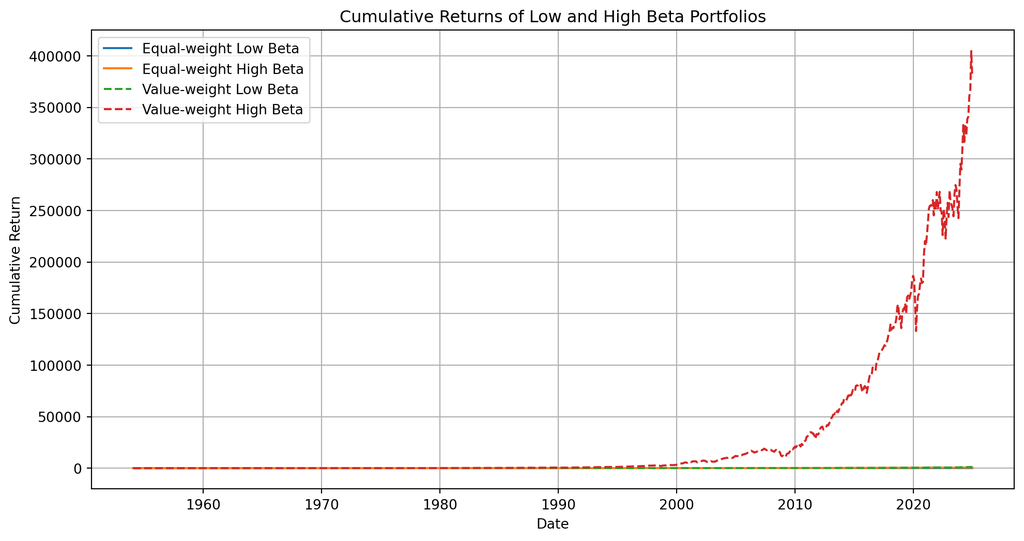

```python
# Plot cumulative returns with datetime x-axis
plt.figure(figsize=(12, 6))
plt.plot(cum_returns.index, cum_returns['ew_low'], label='Equal-weight Low Beta')
plt.plot(cum_returns.index, cum_returns['ew_high'], label='Equal-weight High Beta')
plt.plot(cum_returns.index, cum_returns['vw_low'], label='Value-weight Low Beta', linestyle='--')
plt.plot(cum_returns.index, cum_returns['vw_high'], label='Value-weight High Beta', linestyle='--')

plt.title('Cumulative Returns of Low and High Beta Portfolios')
plt.xlabel('Date')
plt.ylabel('Cumulative Return')
plt.legend()
plt.grid(True)
plt.show()
```